# 統計学2

回帰分析入門

矢内 勇生

2018-05-28

# 準備

## パッケージの読み込み

今回の実習では、**dplyr** というパッケージを利用する。 インストール済みでない場合は、`install.packages()` でまずインストールする。インストールが済んだら、`library()`でパッケージを読み込む。

```r
## install.packages("dplyr", dependencies = TRUE) # インストール済みでない場合のみ実行
library("dplyr")
```

## データの読み込み

前回の実習で使ったデータを利用する。 （前回ダウンロードしていない者は、データ (lec13-data.csv) をダウンロードし、プロジェクト内の data フォルダの中に保存する（このデータは架空のものである）。）

データセットを `read.csv()` で読み込み、 `myd` という名前で利用する。

```r
myd <- read.csv("data/lec13-data.csv")
```

データセットに含まれる変数を確認しよう。

```r
names(myd)
```

```
## [1] "id"       "female"   "support"  "height"   "faheight"
```

このデータセットに含まれているのは、以下の変数である。

- id: 個人のID（識別番号）
- female: 女性であることを表すダミー変数（男性なら0、女性なら1）
- support: 内閣を支持することを表すダミー変数（不支持なら0、支持なら1）
- heihgt: 身長 (cm)
- faheigt: 父親の身長 (cm)

データの一部を確認してみよう。

```r
head(myd)   ## 最初の6行分
```

```
##   id female support height faheight
## 1  1      0       1  174.5    179.0
## 2  2      0       1  171.3    166.4
## 3  3      0       0  174.2    169.7
## 4  4      0       1  173.5    171.5
## 5  5      0       1  169.7    156.5
## 6  6      1       0  157.0    163.1
```

```r
tail(myd)   ## 最後の6行分
```

```
##        id female support height faheight
## 995   995      0       1  172.4    170.0
## 996   996      0       1  172.1    168.8
## 997   997      0       1  170.7    171.4
## 998   998      1       0  161.5    171.9
## 999   999      1       0  159.5    173.5
## 1000 1000      0       1  172.4    169.7
```

# 回帰分析の基礎

## 例題

親子の身長の関係に興味があるとしよう。ここでは、息子の身長 (height) と父親の身長 (faheight) の関係を調べたい。

私たちのデータの height には、息子の身長だけでなく、娘の身長も含まれているので、データセットから息子の行だけ抜き出したい。データセットには、女性を示すfemale という変数が含まれているので、この変数の値が0の行だけ抜き出せばよい。これは、**dplyr** パッケージの `filter()` で実行できる。男性だけのデータセット myd_m を作ってみよう。

```r
myd_m <- filter(myd, female == 0)
```

男性だけ抜き出せたか確認してみよう。

```r
table(myd_m$female)
```

```
##
##   0
## 500
```

female の値がすべて0なので、男性だけ抜き出せたことがわかる。

## 2変数の関係を調べる

息子の身長と父親の身長の関係を調べてみよう。2変数とも量的変数なので、散布図を作り、相関係数を求める。

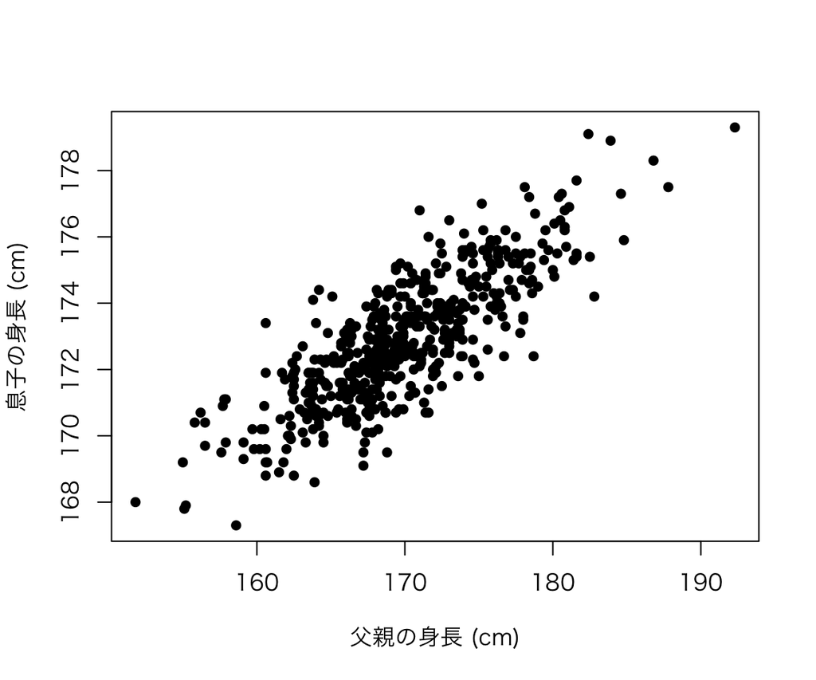

```r
plot(height ~ faheight, data = myd_m, pch = 16,
     xlab = "父親の身長 (cm)", ylab = "息子の身長 (cm)")
```

```r
with(myd_m, cor(height, faheight))
```

```
## [1] 0.8121794
```

散布図と相関係数から、息子の身長と父親の身長の間には、強い正の相関がありそうだということがわかる。

## 原因と結果の関係を想定する

息子の身長と父親の身長の間に正の相関があることはわかった。この2つの変数の関係を理論的に考えてみると、父親の身長が高いことが原因であり、息子の身長が結果であるという関係（遺伝関係）が想定される。つまり、2つの変数には、因果関係がありそうだということが考えられる。では、原因と結果にはどのような関係があるだろうか。

変数間に因果関係が想定されるとき、結果となる変数のことを結果変数 (outcome variable)、原因となる変数のことを説明変数（explanatory variable[s]）と呼んで分析を行う。私たちの例では、

- 結果変数：息子の身長 (height)
- 説明変数：父親の身長 (faheight)

である。

この2つの変数の間に「直線的な」因果関係を想定する。すなわち、次のような関数を想定する。

$$y_n = a + b x_n + \epsilon_n.$$
ただし、$n=1, 2, \dots, N$ （大文字の $N$ が標本サイズ）で、$\epsilon_n$ は誤差（つまり、散布図上ですべての点が直線上に乗るわけではなく、線と点にズレがあることを想定している）である。 直線を求めるとは、$a$ ($y$切片) と $b$（直線の傾き）の値を求めるということである。このような関係を想定して直線を推定することを、「$y$ を $x$ に回帰する (regress $y$ on $x$)」という。

## 回帰直線を求める

息子の身長を父親の身長に回帰しよう。Rで回帰直線 (regression line) を求めるには、`lm()` という関数を使う。**lm** は linear method のイニシャルであり、linear とは「線形」という意味である。大雑把にいうと、直線を推定する方法 (method) ということだ。 `lm()` の使い方は、`lm(結果変数 ~ 説明変数, data = データセットの名前)` である。これに fit（当てはめ）という名前をつけて実行してみよう。

```r
fit <- lm(height ~ faheight, data = myd_m)
```

これで、fit に回帰分析の実行結果が保存された。この結果の詳しい読み方は、『計量経済学』の講義で説明する。

ここでは、$a$ と $b$ の推定値を取り出そう。これらの値は係数（coefficients）と呼ばれており、`coef()` を使うと取り出せる。先ほど保存した fit から係数を取り出してみよう。

```r
coef(fit)
```

```
## (Intercept)    faheight
## 125.9522573   0.2763852
```

値を1つずつ取り出したいときは、次のようにする。

```r
coef(fit)[1]
```

```
## (Intercept)
##    125.9523
```

```r
coef(fit)[2]
```

```
##  faheight
## 0.2763852
```

切片 (intercept) $a$ の推定値が約125.95、父親の身長 (faheight) の係数 $b$ の推定値が約0.28であることがわかる。つまり、求める回帰直線は、
$$\widehat{息子の身長} = 125.95 + 0.28 \times 父親の身長$$
である。 この式で、「息子の身長」の上についている記号は「ハット」と読み、実際の値ではなく予測値（または推定値）であることを示す。

この回帰直線を、図にしてみよう。`plot()` で散布図を描いた後に、`abline()` で直線を引く。`abline()` では、a (切片) と b（直線の傾き）を指定する。

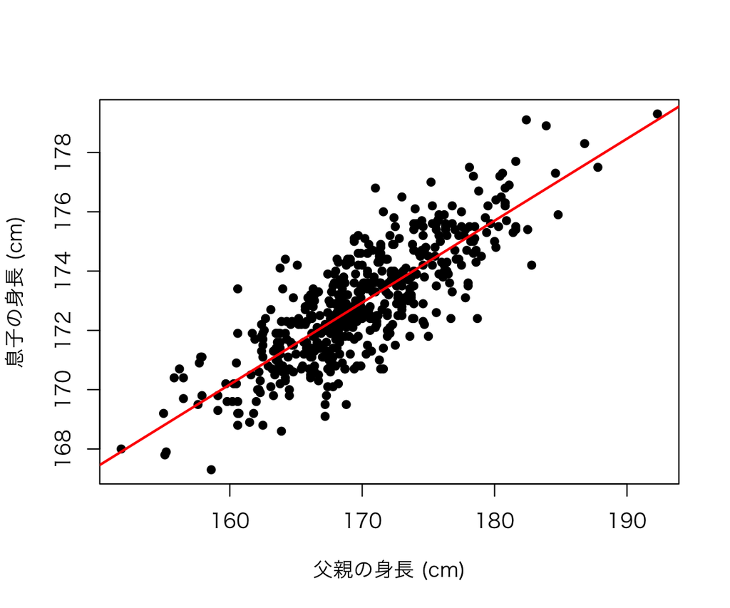

```r
plot(height ~ faheight, data = myd_m, pch = 16,
     xlab = "父親の身長 (cm)", ylab = "息子の身長 (cm)")
abline(a = coef(fit)[1], b = coef(fit)[2], col = "red", lwd = 2)
```

まず、切片である125.95が表しているのは、「父親の身長」が0のときの、息子の身長の予測値である。つまり、父親の身長が0cm であれば、息子の身長は平均すると125.95cm だろうと予測することになる。ただし、身長が0cmの父親は存在しないので、この例では、この数字自体に意味はない（このような意味のない値を推定することを避ける方法は『計量経済学』で解説する）。一般的には、「説明変数の値が0のときの結果変数の予測値」が切片の意味である。

次に、「父親の身長」の係数の推定値である 0.28 は何を意味しているのだろうか。これは、父親の身長が1cm高くなると、息子の身長は平均して0.28cm 高くなるということを示している。つまり、この数値が、説明変数が結果変数に与える影響の強さを表している。 回帰直線は直線なので、父親の身長が10cm高くなると、息子の身長は平均2.8cm高くなると言うこともできる。また、父親の身長が5cm 低くなると、息子の身長は平均 $0.28 \times (-5) = -1.4$cm 高くなる（つまり、1.4cm低くなる）ということもできる。

最後に、予測値を計算してみよう。予測値を計算するためには、説明変数である「父親の身長」に具体的な数値を代入すればよい。 例えば、父親の身長が175cmのときの息子の身長の予測値は、
$$\widehat{息子の身長} = 125.95 + 0.28 \times 175 = 174.95$$
であり、父親の身長が164cm のときは、
$$\widehat{息子の身長} = 125.95 + 0.28 \times 164 = 171.87$$
である。 そして、これらの予測値の集合が、回帰直線である。

**実習課題：** 娘の身長を父親の身長に回帰しなさい。回帰直線を図示し、父親の身長が娘の身長に与える影響について説明しなさい。また、父親の身長が165cm、170cm、175cmのそれぞれの場合について、娘の身長の予測値を求めなさい。

授業の内容に戻る